# Machine Learning for Epi: Assignment 7

2023-03-07

## Description of Data

The data we will be using are from data analyzed by Mattheny et al. 2021, a patient dataset of all inpatients discharged from Vanderbilt University Medical Center between January 1, 2007, and December 31, 2016, with a primary diagnosis of AMI. *We will be using this dataset to predict readmission for myocardial infarction.* We have restricted the dataset to 14 features and an outcome which distinguishes those who were readmitted to the hospital for MI within 30 days of discharge (1=Yes, 0=No).

## Analysis Pipeline

The pipeline for this analysis is outlined below:

1. Data Preparation
   - Removing ID variable
   - Removing missing variables
   - Converting variables to factor when appropriate
   - Check balance
   - Centering and scaling
2. Data partitioning
   - 70/30 split into training and testing data
3. Training
   - 5-fold cross validation on the full training set
   - Train best model based on area under the receiver operating characteristic curve (AUROC) performance metric
   - Downsample data if unbalanced
- Tuning hyperparameters:
  - Elastic Net: alpha and lambda
  - Classification Tree: Cp
  - Random Forest: mtry
4. Comparing model performance
   - Compare AUROC, sensitivity, and specificity across models
   - Select model based on AUROC
5. Apply model to testing data
   - Evaluate confusion matrix
   - Examine variable importance if applicable

### Step 1: Load data and prepare for analysis

```r
mi_data = readr::read_csv("./mi.data.csv") %>%
  mutate(across(.cols = c(Pulm.adema, Arr:readmission), ~ ifelse(. == 1, "Yes", "No"))) %>%
  mutate(Sex = case_when(Sex == 0 ~ "Male",
                         Sex == 1 ~ "Female",
                         Sex == 2 ~ "Non-binary")) %>%
  mutate(FC = case_when(FC == 0 ~ "None",
                         FC == 1 ~ "I",
                         FC == 2 ~ "II",
                         FC == 3 ~ "III",
                         FC == 4 ~ "IV")) %>%
  mutate(Sex = as.factor(Sex),
         Pulm.adema = as.factor(Pulm.adema),
         FC = as.factor(FC),
         Arr = as.factor(Arr),
         Diab = as.factor(Diab),
         Obesity = as.factor(Obesity),
         Asthma = as.factor(Asthma),
         readmission = as.factor(readmission)) %>%
  select(-ID)

# Center and scale mi_data
set.up.preprocess = preProcess(mi_data, method = c("center", "scale"))
mi_data = predict(set.up.preprocess, mi_data)

summary(mi_data)
```

```
##       Age                  Sex           sodium              ALT
##  Min.   :-3.1920   Female    :1064   Min.   :-3.01281   Min.   :-1.1746
##  1st Qu.:-0.7004   Male      : 634   1st Qu.:-0.54879   1st Qu.:-0.6450
##  Median : 0.1005   Non-binary:   2   Median :-0.08678   Median :-0.2478
##  Mean   : 0.0000                     Mean   : 0.00000   Mean   : 0.0000
##  3rd Qu.: 0.7234                     3rd Qu.: 0.52922   3rd Qu.: 0.3613
##  Max.   : 2.6811                     Max.   : 4.99526   Max.   : 6.6906
##       WBC               ESR               SBP                DBP
##  Min.   :-1.9755   Min.   :-1.1171   Min.   :-4.02624   Min.   :-4.2917
##  1st Qu.:-0.6979   1st Qu.:-0.7590   1st Qu.:-0.54652   1st Qu.:-0.6324
##  Median :-0.2334   Median :-0.3113   Median : 0.03343   Median :-0.1096
##  Mean   : 0.0000   Mean   : 0.0000   Mean   : 0.00000   Mean   : 0.0000
##  3rd Qu.: 0.4925   3rd Qu.: 0.4946   3rd Qu.: 0.61339   3rd Qu.: 0.4131
##  Max.   : 5.5446   Max.   :11.3284   Max.   : 3.51315   Max.   : 5.6408
##  Pulm.adema    FC       Arr        Diab      Obesity    Asthma     readmission
##  No :1589   I   : 49   No :1658   No :1472   No :1658   No :1662   No :1541
##  Yes: 111   II  :899   Yes:  42   Yes: 228   Yes:  42   Yes:  38   Yes: 159
##             III : 59
##             IV  : 11
##             None:682
##
```

### Step 2: Partition the data

The code chunk below partitions the data into training and testing sets, using a 70/30 split.

```r
set.seed(123)

#Creating balanced partitions in the data
train_index = createDataPartition(mi_data$readmission, p = 0.7, list = FALSE)

mi_train = mi_data[train_index,]
mi_test = mi_data[-train_index,]

#Check distribution of the outcome between train and test data
summary(mi_train$readmission)
```

```
##   No  Yes
## 1079  112
```

```r
summary(mi_test$readmission)
```

```
##  No Yes
## 462  47
```

We can see that there are similar distributions of the variable `readmission`, with approximately 9% of observations having having to be readmitted across both the training and testing sets, indicating that the data were successfully partitioned.

### Step 3: Model Fitting

We will fit 3 prediction models to predict readmission for MI. (feature name: `readmission`).

- Model 1 (`class_tree`): Classification Tree based on all features.
- Model 2 (`mod_rf`): Random Forest based on all features.
- Model 3 (`mod_EN`): A logistic model based on all features that will serve as our baseline model.

The models will be trained and selected based on the highest Area Under the ROC (AUROC) rather than accuracy, because we want to balance the sensitivity and specificity for readmission classification. This will be done using `summaryFunction = twoClassSummary` and `metric = "ROC"` options within `trainControl()` and `train()` in caret, respectively.

#### Classification Tree

To fit the classification tree, we will tune the complexity hyperparameter using a tune grid of values ranging from 0.01 to 0.04, searching in increments of 0.001. We will use down-sampling because of a 90/10 imbalance of the outcome variable in the data. Moreover, given the small number of outcomes in the training data, we will reduce the number of cross-validation folds to 5.

```r
set.seed(123)

#Creating 10-fold cross-validation and using down-sampling because of imbalance in data
train.control.class = trainControl(method = "cv", number = 5, sampling = "down",
                                   summaryFunction = twoClassSummary, classProbs = TRUE)

#Create sequence of cp parameters to try
grid.2 = expand.grid(cp = seq(0.01, 0.04, by = 0.001))

#Train model
class_tree = train(readmission ~ ., data = mi_train, method = "rpart", trControl = train.control.class, tuneGrid = grid.2, metric = "ROC")

# View results
class_perf = class_tree$results %>% arrange(desc(ROC)) %>% head()
class_perf %>% knitr::kable()
```

| cp | ROC | Sens | Spec | ROCSD | SensSD | SpecSD |
| --- | --- | --- | --- | --- | --- | --- |
| 0.026 | 0.5402931 | 0.4391516 | 0.6237154 | 0.0767599 | 0.1234837 | 0.0986619 |
| 0.027 | 0.5402931 | 0.4391516 | 0.6237154 | 0.0767599 | 0.1234837 | 0.0986619 |
| 0.028 | 0.5402931 | 0.4391516 | 0.6237154 | 0.0767599 | 0.1234837 | 0.0986619 |
| 0.019 | 0.5327217 | 0.4965805 | 0.5616601 | 0.0685976 | 0.1127764 | 0.0467758 |
| 0.020 | 0.5327217 | 0.4965805 | 0.5616601 | 0.0685976 | 0.1127764 | 0.0467758 |
| 0.021 | 0.5327217 | 0.4965805 | 0.5616601 | 0.0685976 | 0.1127764 | 0.0467758 |

```r
# Obtain variable importance on the final model within training data
varImp(class_tree)
```

```
## rpart variable importance
##
##                 Overall
## WBC             100.000
## SBP              64.603
## sodium           61.808
## DBP              57.459
## ESR              46.127
## Age              44.435
## FCNone           37.627
## Pulm.ademaYes    33.949
## ALT              20.204
## FCII              4.903
## SexMale           0.000
## DiabYes           0.000
## ArrYes            0.000
## FCIV              0.000
## `SexNon-binary`   0.000
## ObesityYes        0.000
## FCIII             0.000
## AsthmaYes         0.000
```

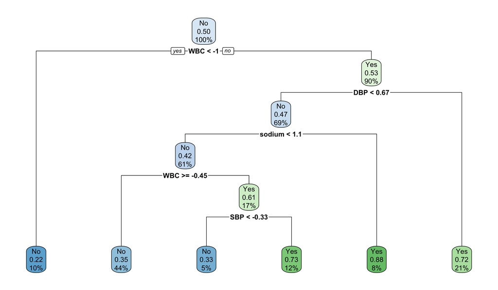

```r
# Plot classification tree
rpart.plot(class_tree$finalModel)
```

```r
# Save results
class_perf = class_perf %>% slice(1) %>% select(-cp)
```

#### Random Forest Model

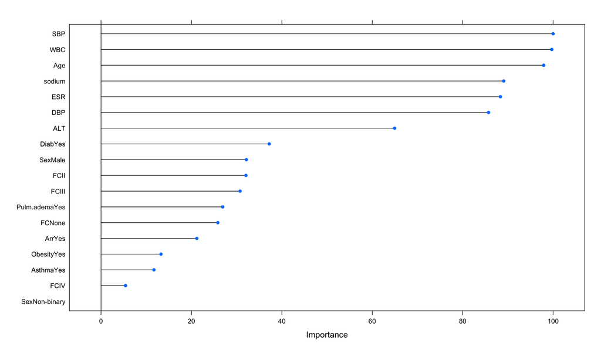

```r
set.seed(123)

#Set 5-fold cross-validation and downsample
train_control = trainControl(method = "cv", number = 5, sampling = "down",
                             classProbs = T, summaryFunction = twoClassSummary)

#Trying grid of values of mtry
mtry.grid = expand.grid(.mtry = seq(1, 14, by = 1))

mod_rf = train(readmission ~ ., data = mi_train, method = "rf", metric = "ROC", tuneGrid = mtry.grid,
               trControl = train_control,
               ntree = 200)

plot(varImp(mod_rf))
```

```r
# View results
rf_perf = mod_rf$results %>% arrange(desc(ROC)) %>% head()
rf_perf %>% knitr::kable()
```

| mtry | ROC | Sens | Spec | ROCSD | SensSD | SpecSD |
| --- | --- | --- | --- | --- | --- | --- |
| 1 | 0.5830874 | 0.5441214 | 0.6055336 | 0.0859948 | 0.0872587 | 0.1168233 |
| 8 | 0.5825242 | 0.5431309 | 0.5806324 | 0.0616719 | 0.0301939 | 0.0651335 |
| 14 | 0.5718915 | 0.5375581 | 0.6075099 | 0.0426033 | 0.0298136 | 0.0547613 |
| 11 | 0.5718847 | 0.5495349 | 0.6162055 | 0.0434852 | 0.0407468 | 0.0966300 |
| 3 | 0.5678427 | 0.5570026 | 0.5347826 | 0.0626253 | 0.0117928 | 0.1061837 |
| 13 | 0.5669067 | 0.5208570 | 0.5889328 | 0.0340179 | 0.0312330 | 0.1239951 |

```r
# Save results
rf_perf = rf_perf %>%
  slice(1) %>%
  select(-mtry)
```

The resulting model found that for the highest model performance AUROC of 58.31%, the optimal mtry hyperparameter value was 1, which suggests that random sampling single variable to split for each tree was sufficient for higher model performance. We can see that the most important variables in the random forest in descending order of importance include SBP, WBC, and Age, which are similar to the results we find in the classification tree, where WBC and SBP were the most important variables.

#### Elastic Net Regression Model

To fit the elastic model, we will feed all features into the model, and train within caret using 5-fold CV and down-sampling. We will set the tune length to 100 for the number of combinations to search for alpha and lambda.

```r
set.seed(123)

train_control = trainControl(method = "cv", number = 5, sampling = "down", classProbs = T, summaryFunction = twoClassSummary)

mod_EN = train(readmission ~ ., data = mi_train, method = "glmnet",
               trControl = train_control,
               tuneLength = 100)

#Print the values of alpha and lambda that gave best prediction
mod_EN$bestTune
```

```
##          alpha    lambda
## 1153 0.2636364 0.0298305
```

```r
# View results
EN_perf = mod_EN$results %>% arrange(desc(ROC)) %>% head()
EN_perf %>% knitr::kable()
```

| alpha | lambda | ROC | Sens | Spec | ROCSD | SensSD | SpecSD |
| --- | --- | --- | --- | --- | --- | --- | --- |
| 0.2636364 | 0.0298305 | 0.6238498 | 0.5541430 | 0.6521739 | 0.0372825 | 0.0520025 | 0.0846925 |
| 0.2636364 | 0.0326787 | 0.6231892 | 0.5550732 | 0.6521739 | 0.0370590 | 0.0502313 | 0.0846925 |
| 0.2636364 | 0.0272306 | 0.6230634 | 0.5513609 | 0.6521739 | 0.0380950 | 0.0542509 | 0.0846925 |
| 0.2636364 | 0.0429612 | 0.6226586 | 0.5448837 | 0.6608696 | 0.0389044 | 0.0486980 | 0.0868959 |
| 0.2636364 | 0.0357988 | 0.6223939 | 0.5550689 | 0.6521739 | 0.0368684 | 0.0509307 | 0.0846925 |
| 0.2636364 | 0.0248572 | 0.6222667 | 0.5522868 | 0.6434783 | 0.0379528 | 0.0539842 | 0.0868959 |

```r
# Save results
EN_perf = EN_perf %>%
  slice(1) %>%
  select(-alpha, -lambda)
```

The resulting model yielded an AUROC of 62.385%, with hyperparameters of alpha = 0.264 and lambda = 0.0298.

#### Comparing performance across models

Finally, let’s compare the performance results on the training data across the 3 models.

```r
rbind(class_perf, rf_perf, EN_perf) %>%
  mutate(Model = c("Classification Tree", "Random Forest", "Elastic Net")) %>%
  relocate(Model) %>%
  arrange(desc(ROC)) %>%
  knitr::kable(digits = 4)
```

| Model | ROC | Sens | Spec | ROCSD | SensSD | SpecSD |
| --- | --- | --- | --- | --- | --- | --- |
| Elastic Net | 0.6238 | 0.5541 | 0.6522 | 0.0373 | 0.0520 | 0.0847 |
| Random Forest | 0.5831 | 0.5441 | 0.6055 | 0.0860 | 0.0873 | 0.1168 |
| Classification Tree | 0.5403 | 0.4392 | 0.6237 | 0.0768 | 0.1235 | 0.0987 |

### Step 4: Final Model Evaluation

Finally, we will evaluate the performance our final Elastic Net model by making predictions in the test data. We will use the `confusionMatrix()` function to get performance measures of sensitivity, specificity, NPV, and PPV, and accuracy for the model, and plot the ROC curve.

```r
# Make predictions in test set
pred = mod_EN %>% predict(mi_test)
mi_test = mi_test %>% mutate(pred = as.factor(pred))

# Get evaluation metrics from test set
cm = confusionMatrix(data = mi_test$pred, reference = mi_test$readmission, positive = "Yes")

#Create ROC Curve for Analysis
pred_prob <- predict(mod_EN, mi_test, type = "prob")

# Plot Area under the Receiver Operating Curve (AUROC)
analysis =  roc(response = mi_test$readmission, predictor = pred_prob[,2])

# View results
cm
```

```
## Confusion Matrix and Statistics
##
##           Reference
## Prediction  No Yes
##        No  250  18
##        Yes 212  29
##
##                Accuracy : 0.5481
##                  95% CI : (0.5037, 0.592)
##     No Information Rate : 0.9077
##     P-Value [Acc > NIR] : 1
##
##                   Kappa : 0.0554
##
##  Mcnemar's Test P-Value : <2e-16
##
##             Sensitivity : 0.61702
##             Specificity : 0.54113
##          Pos Pred Value : 0.12033
##          Neg Pred Value : 0.93284
##              Prevalence : 0.09234
##          Detection Rate : 0.05697
##    Detection Prevalence : 0.47348
##       Balanced Accuracy : 0.57907
##
##        'Positive' Class : Yes
##
```

```r
analysis$auc
```

```
## Area under the curve: 0.5972
```

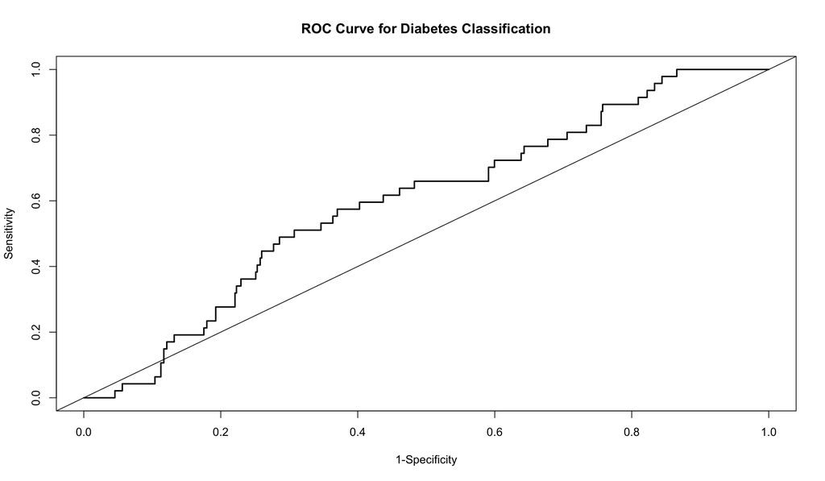

```r
plot(1 - analysis$specificities, analysis$sensitivities, type = "l",
ylab = "Sensitivity",xlab = "1-Specificity", col = "black", lwd = 2,
main = "ROC Curve for Diabetes Classification")
abline(a = 0, b = 1)
```